# 自組織映射網路 (Self-Organizing Map)

JianKai Wang (https://sophia.ddns.net/)

2018年4月3日

## 自組織映射網路(SOM)

Self-Organizing Map (SOM) 網路亦為 Kohonen 神經網路，透過反覆運算優化目標函式來達成對資料分群 (Clustering)。SOM 為非監督學習的一類，優點為可將 N 維度的資料映射(mapping)至 2 維的空間上，並維持資料中的拓樸特性。其次，可透過調整權重係數，促使神經網路收斂。

### SOM 架構與擬合

SOM 神經網路是一個兩層前饋神經網路，僅含輸入層與輸出層，兩層間的各神經元是連接的，網路中沒有隱含層，輸入層含有 m 個神經元，神經元個數與輸入樣本的特徵數相同，而輸出層有 n 個神經元，神經元間與鄰近的神經元兩兩相接，故 SOM 中兩類型的權值：

1. 輸入神經元與輸出神經元間的連接權值
2. 輸出神經元間的側向連接權值

SOM 架構如下圖:

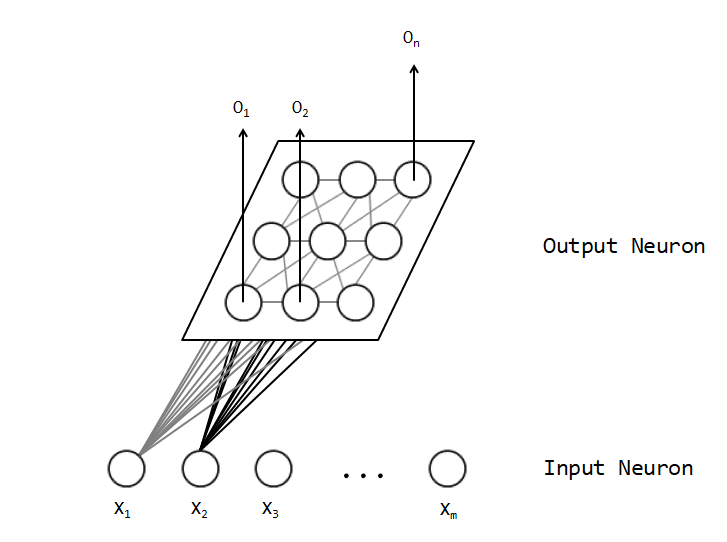

SOM 神經網路採用競爭學習演算法，在學習過程中相互競爭，對於每次輸入的樣本向量，對競爭勝利的神經元與鄰近神經元進行權重係數的修改，其他區域神經元的權重則不變。

### SOM 優缺點

- 優點
  - 具有神經網路的特性與優勢，如平行處理、分散式儲存、容錯力等
  - 具有分群的優點
  - 透過競爭學習，訓練權重係數後，自動得出各分群的中心
  - 不須事先指定分群數目
  - 支援大數量的分群結果，有效找出異常資料類且網路訓練收斂速度快
- 缺點
  - 輸入資料少時，分群結果與資料輸入先後順序有關
  - 與 adaptive resonance theory network (art) 不同，在學習完成前，不能加入新的類別

### 安裝套件

```r
packageName <- c("kohonen")
for(i in 1:length(packageName)) {
  if(!(packageName[i] %in% rownames(installed.packages()))) {
    install.packages(packageName[i])
  }
}
lapply(packageName, require, character.only = TRUE)
```

```
## [[1]]
## [1] TRUE
```

### 資料準備

使用 kohonen 套件內建的資料 wines。wines 收集多筆酒的特徵資料，包含頻果酸(malic acid), 鎂(magnesium), 酚類數值(tot. phenols) 等。

```r
data(wines)
head(wines, 5)
```

```
##      alcohol malic acid  ash ash alkalinity magnesium tot. phenols
## [1,]   13.20       1.78 2.14           11.2       100         2.65
## [2,]   13.16       2.36 2.67           18.6       101         2.80
## [3,]   14.37       1.95 2.50           16.8       113         3.85
## [4,]   13.24       2.59 2.87           21.0       118         2.80
## [5,]   14.20       1.76 2.45           15.2       112         3.27
##      flavonoids non-flav. phenols proanth col. int. col. hue OD ratio
## [1,]       2.76              0.26    1.28      4.38     1.05     3.40
## [2,]       3.24              0.30    2.81      5.68     1.03     3.17
## [3,]       3.49              0.24    2.18      7.80     0.86     3.45
## [4,]       2.69              0.39    1.82      4.32     1.04     2.93
## [5,]       3.39              0.34    1.97      6.75     1.05     2.85
##      proline
## [1,]    1050
## [2,]    1185
## [3,]    1480
## [4,]     735
## [5,]    1450
```

```r
som.data.idx <- sample(nrow(wines), 100)
som.training.data <- wines[som.data.idx, ]
som.testing.data <- wines[-som.data.idx, ]
```

### 建立 SOM 模型

```r
# the prototype of som
# data: 已經 scale 的資料框
# grid:
# |- somgrid: 依照 x, y 及拓樸方法產生一系列網路的單元，此也決定輸出神經元數目
#   |- xdim: (繪圖時) x 方向神經元數
#   |- ydim: (繪圖時) y 方向神經元數
#   |- topo: (繪圖時)呈現方式，有 "hexagonal" 與 "rectangular" 兩類
#   |- neighbourhood.fct: 輸出神經元之間的相鄰函式，有 "gaussian" 與 "bubble" 兩類
som(data, grid = somgrid(xdim,ydim,topo="hexagonal",neighbourhood.fct="gaussian"))
```

```r
# scale 目的將值進行調整，可分為有中心(center = TRUE)或無中心(center = FALSE)兩類
som.training.data.scale <- scale(som.training.data)
som.model <- som(som.training.data.scale, grid = somgrid(5,5,"hexagonal","gaussian"))
summary(som.model)
```

```
## SOM of size 5x5 with a hexagonal topology and a gaussian neighbourhood function.
## Training data included of 100 objects
## The number of layers is 1
## Mean distance to the closest unit in the map: 3.491524
```

由可以看出 SOM 為一個 5x5 hexagonal 狀的拓樸，輸出神經元相鄰函式使用 gaussian。

### 繪出輸出神經元及輸出層資訊

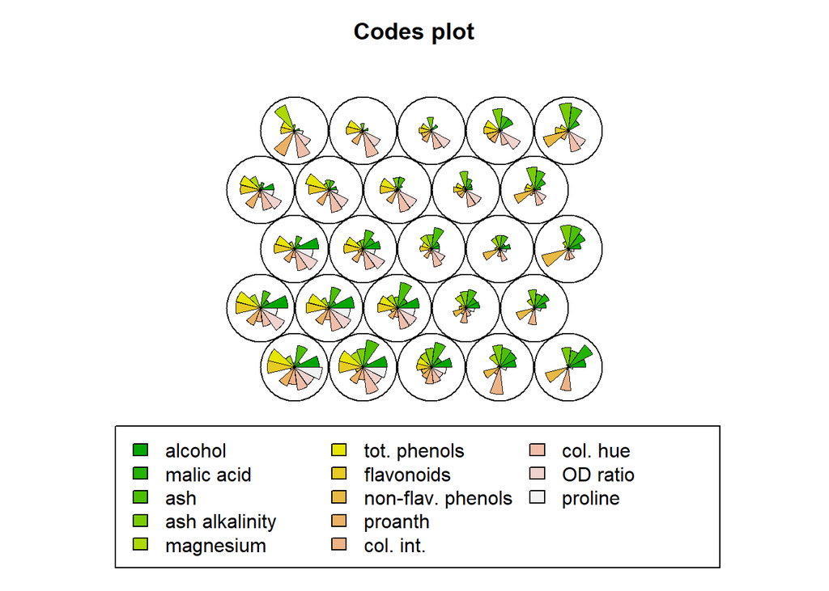

```r
# type 為繪圖方式，預設為 codes，有其他含 changes, counts, mappng, ... 等
plot(som.model, type="codes")
```

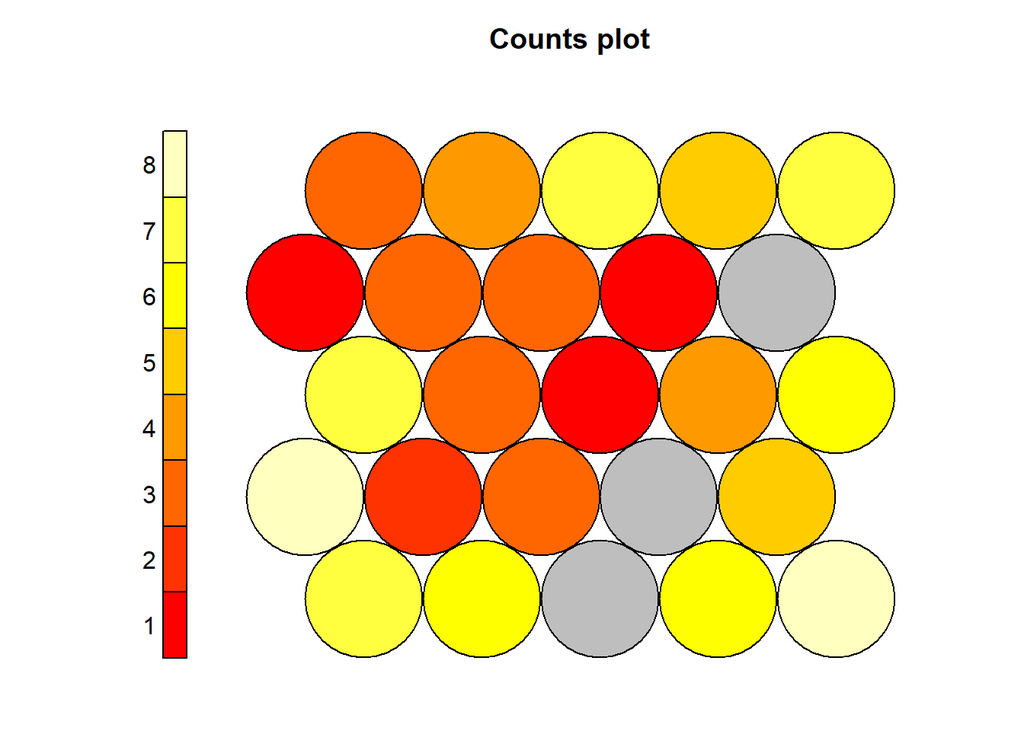

```r
plot(som.model, type="counts")
```

### 預測資料

SOM 為非監督式學習，透過 **predict** 函式可以了解每筆測試資料屬於哪個神經元的分群結果。

```r
som.testing.data.scale <- scale(som.testing.data)
som.pred <- predict(som.model, som.testing.data.scale)

# 顯示出分群結果
som.pred$unit.classif
```

```
##  [1]  1  8  1  8  1  7  1  1 12  2  7  2  7  8 11 12  6  7  1 16  6  2 22
## [24] 14 22 13 17 22 12 13 20 18 18 19 25 20 25 20 18 18 22 23 20 21 19 18
## [47] 24 18 19 14  2 24 24 24 24  9  9 14 10 15  5 15 10 15  5  4  4  4  5
## [70]  4  4  5  4  4 10  4  4
```